# Titanic: Machine Learning from Disaster

### Sex 전처리

male: 0 female: 1

```python
sex_mapping = {"male": 0, "female": 1}
for dataset in train_test_data:
    dataset['Sex'] = dataset['Sex'].map(sex_mapping)
```

```python
train['Sex'].unique()
```

```
array([0, 1], dtype=int64)
```

```python
# bar_chart('Sex')
```

### Age 전처리

- 누락값 NaN
- 연속데이타를 카테고리화

  ```
  child: 0
  young: 1
  adult: 2
  mid-age: 3
  senior: 4
  ```

```python
# train.head(100)
```

```python
train.groupby("Title")["Age"].median()
```

```
Title
0    30.0
1    21.0
2    35.0
3     9.0
Name: Age, dtype: float64
```

```python
# 누락값 채우기
train["Age"].fillna(train.groupby("Title")["Age"].transform("median"), inplace=True)
test["Age"].fillna(test.groupby("Title")["Age"].transform("median"), inplace=True)
```

```python
# train.info()
test.info()
```

```
<class 'pandas.core.frame.DataFrame'>
RangeIndex: 418 entries, 0 to 417
Data columns (total 11 columns):
PassengerId    418 non-null int64
Pclass         418 non-null int64
Sex            418 non-null int64
Age            418 non-null float64
SibSp          418 non-null int64
Parch          418 non-null int64
Ticket         418 non-null object
Fare           417 non-null float64
Cabin          91 non-null object
Embarked       418 non-null object
Title          418 non-null int64
dtypes: float64(2), int64(6), object(3)
memory usage: 36.0+ KB
```

```python
# train.head(30)
# train.groupby("Title")["Age"].transform("median")
```

## Age & Survied - FacetGrid 시각화

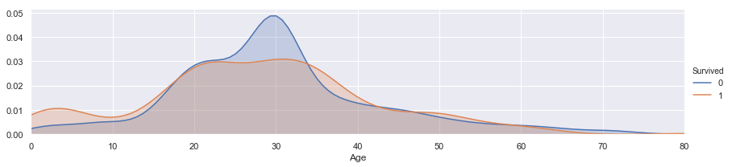

```python
facet = sns.FacetGrid(train, hue="Survived",aspect=4)
facet.map(sns.kdeplot,'Age',shade= True)
facet.set(xlim=(0, train['Age'].max()))
facet.add_legend()

plt.show()
```

```python
train.info()
```

```
<class 'pandas.core.frame.DataFrame'>
RangeIndex: 891 entries, 0 to 890
Data columns (total 12 columns):
PassengerId    891 non-null int64
Survived       891 non-null int64
Pclass         891 non-null int64
Sex            891 non-null int64
Age            891 non-null float64
SibSp          891 non-null int64
Parch          891 non-null int64
Ticket         891 non-null object
Fare           891 non-null float64
Cabin          204 non-null object
Embarked       889 non-null object
Title          891 non-null int64
dtypes: float64(2), int64(7), object(3)
memory usage: 83.6+ KB
```

## Age 카테고리화

- 구간 분류 후 숫자값으로 채우기 Binning/Converting Numerical Age to Categorical Variable

```
feature vector map:
child: 0 // ~16
young: 1 // 17 ~ 26
adult: 2 // 27 ~ 36
mid-age: 3  // 37 ~ 62
senior: 4  // 63 ~
```

```python
# train_test_data
```

```python
for dataset in train_test_data:
    dataset.loc[ dataset['Age'] <= 16, 'Age'] = 0,
    dataset.loc[(dataset['Age'] > 16) & (dataset['Age'] <= 26), 'Age'] = 1,
    dataset.loc[(dataset['Age'] > 26) & (dataset['Age'] <= 36), 'Age'] = 2,
    dataset.loc[(dataset['Age'] > 36) & (dataset['Age'] <= 62), 'Age'] = 3,
    dataset.loc[ dataset['Age'] > 62, 'Age'] = 4
```

```python
# test[test['Age'] > 0]
```

```python
test['Age'].unique()
```

```
array([2., 3., 1., 0., 4.])
```

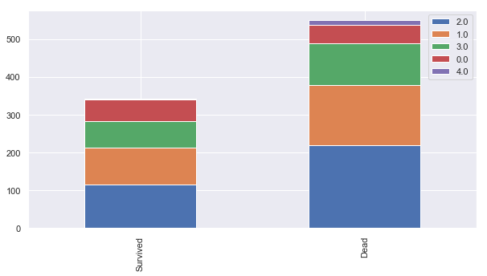

```python
bar_chart('Age')
```

## Embarked 전처리

- Embarked는 종속변수?

## filling missing values

```python
# Pclass별 Embarked 카운팅
#

Pclass1 = \
    train[train['Pclass']==1]['Embarked'].value_counts()
Pclass2 = \
    train[train['Pclass']==2]['Embarked'].value_counts()
Pclass3 = \
    train[train['Pclass']==3]['Embarked'].value_counts()

print(Pclass1)
print(Pclass2)
print(Pclass3)
```

```
S    127
C     85
Q      2
Name: Embarked, dtype: int64
S    164
C     17
Q      3
Name: Embarked, dtype: int64
S    353
Q     72
C     66
Name: Embarked, dtype: int64
```

```python
# 각 클래스별로 데이타프레임 별도 생성
df = pd.DataFrame([Pclass1, Pclass2, Pclass3])
df.index = ['1st class','2nd class', '3rd class']
df
```

|  | S | C | Q |
| --- | --- | --- | --- |
| 1st class | 127 | 85 | 2 |
| 2nd class | 164 | 17 | 3 |
| 3rd class | 353 | 66 | 72 |

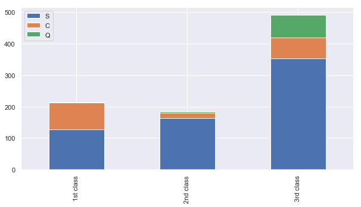

```python
df.plot(kind='bar',stacked=True, figsize=(10,5))
```

** embark Missing Value

more than 50% of 1st class are from S embark  
more than 50% of 2nd class are from S embark  
more than 50% of 3rd class are from S embark

Result =? S

```python
# 최빈값 S 로 결측값 채우기
for dataset in train_test_data:
    dataset['Embarked'] = \
        dataset['Embarked'].fillna('S')
```

```python
# train.head()
```

```python
train['Embarked'].isnull().sum()
```

```
0
```

```python
# 숫자로 변경하기
embarked_mapping = {"S": 0, "C": 1, "Q": 2}
for dataset in train_test_data:
    dataset['Embarked'] = \
        dataset['Embarked'].map(embarked_mapping)
```

```python
train['Embarked'].value_counts()
```

```
0    646
1    168
2     77
Name: Embarked, dtype: int64
```

### Fare 전처리

- NaN
- 카테고리화

```python
# NaN  확인
# train['Fare'].isnull().sum()
test['Fare'].isnull().sum()
```

```
1
```

```python
train['Fare'].unique()
train['Fare'].value_counts()
train['Fare'].max(), train['Fare'].min()
```

```
(512.3292, 0.0)
```

```python
train.groupby("Pclass")["Fare"].max()
train.groupby("Pclass")["Fare"].min()
train.groupby("Pclass")["Fare"].median()
train.groupby("Pclass")["Fare"].mean()
```

```
Pclass
1    84.154687
2    20.662183
3    13.675550
Name: Fare, dtype: float64
```

```python
# 각 Pclass의 중앙값으로  NaN으로 채운다
# fill missing Fare with median fare for each Pclass
train["Fare"].fillna(train.groupby("Pclass")["Fare"].transform("median"), inplace=True)
test["Fare"].fillna(test.groupby("Pclass")["Fare"].transform("median"), inplace=True)
# train.head(50)
```

```python
# 평균값으로 결측치 채우기
test["Fare"].fillna(test['Fare'].mean(), inplace=True)
```

```python
# NaN  확인
# train['Fare'].isnull().sum()
test['Fare'].isnull().sum()
```

```
0
```

### Fare 값 변경

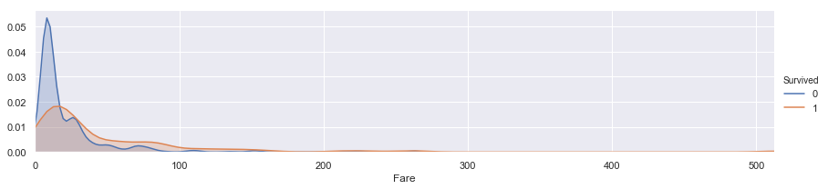

```python
facet = sns.FacetGrid(train, hue="Survived",aspect=4)
facet.map(sns.kdeplot,'Fare',shade= True)
facet.set(xlim=(0, train['Fare'].max()))
facet.add_legend()

plt.show()
```

```
(0, 20)
```

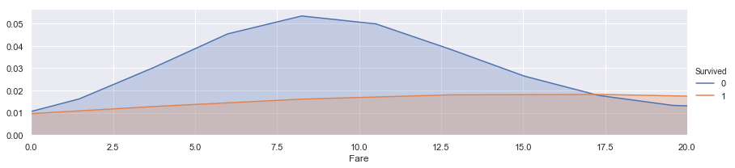

```python
facet = sns.FacetGrid(train, hue="Survived",aspect=4)
facet.map(sns.kdeplot,'Fare',shade= True)
facet.set(xlim=(0, train['Fare'].max()))
facet.add_legend()
plt.xlim(0, 20)
```

```
(0, 30)
```

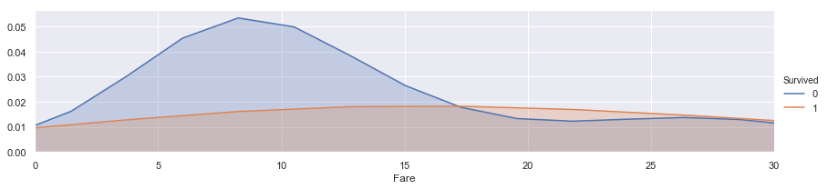

```python
facet = sns.FacetGrid(train, hue="Survived",aspect=4)
facet.map(sns.kdeplot,'Fare',shade= True)
facet.set(xlim=(0, train['Fare'].max()))
facet.add_legend()
plt.xlim(0, 30)
```

```
(0, 100)
```

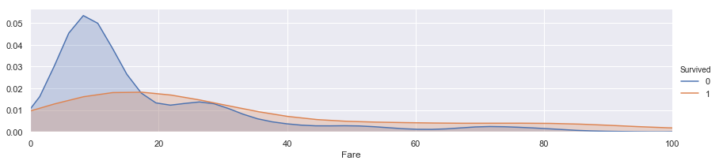

```python
facet = sns.FacetGrid(train, hue="Survived",aspect=4)
facet.map(sns.kdeplot,'Fare',shade= True)
facet.set(xlim=(0, train['Fare'].max()))
facet.add_legend()
plt.xlim(0,100)
```

#### Feature Scale

```
0 : Fare <=17
1 : 17 < Fare <= 30
2 : 30 < Fare <= 100
3 : 100 < Fare
```

```python
train['Fare'].describe()
```

```
count    891.000000
mean      32.204208
std       49.693429
min        0.000000
25%        7.910400
50%       14.454200
75%       31.000000
max      512.329200
Name: Fare, dtype: float64
```

```python
# for dataset in train_test_data:
#     dataset.loc[ dataset['Fare'] <= 17, 'Fare'] = 0,
#     dataset.loc[(dataset['Fare'] > 17) & (dataset['Fare'] <= 30), 'Fare'] = 1,
#     dataset.loc[(dataset['Fare'] > 30) & (dataset['Fare'] <= 100), 'Fare'] = 2,
#     dataset.loc[ dataset['Fare'] > 100, 'Fare'] = 3
```

```python
# train['Fare'].unique()
test['Fare'].unique()
```

```
array([  7.8292,   7.    ,   9.6875,   8.6625,  12.2875,   9.225 ,
         7.6292,  29.    ,   7.2292,  24.15  ,   7.8958,  26.    ,
        82.2667,  61.175 ,  27.7208,  12.35  ,   7.225 ,   7.925 ,
        59.4   ,   3.1708,  31.6833,  61.3792, 262.375 ,  14.5   ,
        61.9792,  30.5   ,  21.6792,  31.5   ,  20.575 ,  23.45  ,
        57.75  ,   8.05  ,   9.5   ,  56.4958,  13.4167,  26.55  ,
         7.85  ,  13.    ,  52.5542,  29.7   ,   7.75  ,  76.2917,
        15.9   ,  60.    ,  15.0333,  23.    , 263.    ,  15.5792,
        29.125 ,   7.65  ,  16.1   ,  13.5   ,   7.725 ,  21.    ,
         7.8792,  42.4   ,  28.5375, 211.5   ,  25.7   ,  15.2458,
       221.7792,  10.7083,  14.4542,  13.9   ,   7.775 ,  52.    ,
         7.7958,  78.85  ,   7.8542,  55.4417,   8.5167,  22.525 ,
         7.8208,   8.7125,  15.0458,   7.7792,  31.6792,   7.2833,
         6.4375,  16.7   ,  75.2417,  15.75  ,   7.25  ,  23.25  ,
        28.5   ,  25.4667,  46.9   , 151.55  ,  18.    ,  51.8625,
        83.1583,  12.1833,  31.3875,   7.55  ,  13.775 ,   7.7333,
        22.025 ,  50.4958,  34.375 ,   8.9625,  39.    ,  36.75  ,
        53.1   , 247.5208,  16.    ,  69.55  ,  32.5   , 134.5   ,
        10.5   ,   8.1125,  15.5   ,  14.4   , 227.525 ,  25.7417,
         7.05  ,  73.5   ,  42.5   , 164.8667,  13.8583,  27.4458,
        15.1   ,  65.    ,   6.4958,  71.2833,  75.25  , 106.425 ,
        30.    ,   7.8875,  27.75  , 136.7792,   9.325 ,  17.4   ,
        12.7375,   0.    ,  20.2125,  39.6   ,   6.95  ,  81.8583,
        41.5792,  45.5   ,   9.35  ,  93.5   ,  14.1083,   7.575 ,
       135.6333, 146.5208, 211.3375,  79.2   ,  15.7417,   7.5792,
       512.3292,  63.3583,  51.4792,  15.55  ,  37.0042,  14.4583,
        39.6875,  11.5   ,  50.    ,  12.875 ,  21.075 ,  39.4   ,
        20.25  ,  47.1   ,  13.8625,   7.7208,  90.    , 108.9   ,
        22.3583])
```

```python
train.head(10)
```

|  | PassengerId | Survived | Pclass | Sex | Age | SibSp | Parch | Ticket | Fare | Cabin | Embarked | Title |
| --- | --- | --- | --- | --- | --- | --- | --- | --- | --- | --- | --- | --- |
| 0 | 1 | 0 | 3 | 0 | 1.0 | 1 | 0 | A/5 21171 | 7.2500 | NaN | 0 | 0 |
| 1 | 2 | 1 | 1 | 1 | 3.0 | 1 | 0 | PC 17599 | 71.2833 | C85 | 1 | 2 |
| 2 | 3 | 1 | 3 | 1 | 1.0 | 0 | 0 | STON/O2. 3101282 | 7.9250 | NaN | 0 | 1 |
| 3 | 4 | 1 | 1 | 1 | 2.0 | 1 | 0 | 113803 | 53.1000 | C123 | 0 | 2 |
| 4 | 5 | 0 | 3 | 0 | 2.0 | 0 | 0 | 373450 | 8.0500 | NaN | 0 | 0 |
| 5 | 6 | 0 | 3 | 0 | 2.0 | 0 | 0 | 330877 | 8.4583 | NaN | 2 | 0 |
| 6 | 7 | 0 | 1 | 0 | 3.0 | 0 | 0 | 17463 | 51.8625 | E46 | 0 | 0 |
| 7 | 8 | 0 | 3 | 0 | 0.0 | 3 | 1 | 349909 | 21.0750 | NaN | 0 | 3 |
| 8 | 9 | 1 | 3 | 1 | 2.0 | 0 | 2 | 347742 | 11.1333 | NaN | 0 | 2 |
| 9 | 10 | 1 | 2 | 1 | 0.0 | 1 | 0 | 237736 | 30.0708 | NaN | 1 | 2 |

```python
# train['Fare'].value_counts()
test['Fare'].value_counts()
```

```
7.7500      21
26.0000     19
8.0500      17
13.0000     17
7.8958      12
10.5000     11
7.7750      10
7.2292       9
7.2250       9
8.6625       8
7.8542       8
21.0000      8
26.5500      7
7.8792       6
27.7208      6
7.2500       5
7.9250       5
262.3750     5
211.5000     4
69.5500      4
14.5000      4
7.5500       4
7.7958       4
15.2458      4
55.4417      3
31.3875      3
31.5000      3
14.4542      3
9.5000       3
221.7792     3
            ..
50.4958      1
39.4000      1
34.3750      1
7.7208       1
7.8500       1
76.2917      1
7.7250       1
9.2250       1
39.6875      1
75.2500      1
13.8625      1
6.9500       1
61.1750      1
78.8500      1
20.2125      1
247.5208     1
7.5750       1
28.5375      1
227.5250     1
108.9000     1
6.4958       1
7.6292       1
47.1000      1
22.3583      1
17.4000      1
9.3250       1
14.4583      1
15.0333      1
25.4667      1
21.0750      1
Name: Fare, Length: 169, dtype: int64
```

### Cabin

- NaN
- Pclass와 상관관계

```python
# train.Cabin.value_counts()
```

```python
# train['Cabin'].unique()
```

```python
# Cabin의 첫글자만 추출한 후 값 대체
for dataset in train_test_data:
    dataset['Cabin'] = dataset['Cabin'].str[:1]
```

```python
train['Cabin'].unique()
```

```
array([nan, 'C', 'E', 'G', 'D', 'A', 'B', 'F', 'T'], dtype=object)
```

```python
train.Cabin.value_counts()
```

```
C    59
B    47
D    33
E    32
A    15
F    13
G     4
T     1
Name: Cabin, dtype: int64
```

#### Pclass & Cabin

```python
Pclass1 = \
    train[train['Pclass']==1]['Cabin'].value_counts()
Pclass2 = \
    train[train['Pclass']==2]['Cabin'].value_counts()
Pclass3 = \
    train[train['Pclass']==3]['Cabin'].value_counts()
df = pd.DataFrame([Pclass1, Pclass2, Pclass3])
df.index = ['1st class','2nd class', '3rd class']
df
# 1등급은 C, B, A, T
# 2등급은 D, E, F
# 3등급은 E, F, G
```

|  | C | B | D | E | A | T | F | G |
| --- | --- | --- | --- | --- | --- | --- | --- | --- |
| 1st class | 59.0 | 47.0 | 29.0 | 25.0 | 15.0 | 1.0 | NaN | NaN |
| 2nd class | NaN | NaN | 4.0 | 4.0 | NaN | NaN | 8.0 | NaN |
| 3rd class | NaN | NaN | NaN | 3.0 | NaN | NaN | 5.0 | 4.0 |

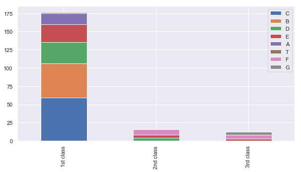

```python
df.plot(kind='bar',stacked=True, figsize=(10,5))
```

#### Cabin 숫자화

- A: 0, B: 0.4, C: 0.8, D: 1.2,
- E: 1.6, F: 2, G: 2.4, T: 2.8

```python
cabin_mapping = \
{"A": 0, "B": 0.4, "C": 0.8,
 "D": 1.2, "E": 1.6, "F": 2,
 "G": 2.4, "T": 2.8}
for dataset in train_test_data:
    dataset['Cabin'] = \
        dataset['Cabin'].map(cabin_mapping)
```

```python
# Pclass의 중간값으로
train["Cabin"].fillna(
    train.groupby("Pclass")["Cabin"].
    transform("median"), inplace=True)
test["Cabin"].fillna(
    test.groupby("Pclass")["Cabin"]
    .transform("median"), inplace=True)
```

```python
train["Cabin"].value_counts()
```

```
2.0    492
1.8    168
0.8     99
0.4     47
1.2     33
1.6     32
0.0     15
2.4      4
2.8      1
Name: Cabin, dtype: int64
```

```python
train["Cabin"].isnull().sum()
```

```
0
```

### FamilySize(SibSp+Parch)

```python
train["FamilySize"] = train["SibSp"] + train["Parch"] + 1
test["FamilySize"] = test["SibSp"] + test["Parch"] + 1
```

```python
train.head()
test.head()
```

|  | PassengerId | Pclass | Sex | Age | SibSp | Parch | Ticket | Fare | Cabin | Embarked | Title | FamilySize |
| --- | --- | --- | --- | --- | --- | --- | --- | --- | --- | --- | --- | --- |
| 0 | 892 | 3 | 0 | 2.0 | 0 | 0 | 330911 | 7.8292 | 2.0 | 2 | 0 | 1 |
| 1 | 893 | 3 | 1 | 3.0 | 1 | 0 | 363272 | 7.0000 | 2.0 | 0 | 2 | 2 |
| 2 | 894 | 2 | 0 | 3.0 | 0 | 0 | 240276 | 9.6875 | 2.0 | 2 | 0 | 1 |
| 3 | 895 | 3 | 0 | 2.0 | 0 | 0 | 315154 | 8.6625 | 2.0 | 0 | 0 | 1 |
| 4 | 896 | 3 | 1 | 1.0 | 1 | 1 | 3101298 | 12.2875 | 2.0 | 0 | 2 | 3 |

```
(0, 11.0)
```

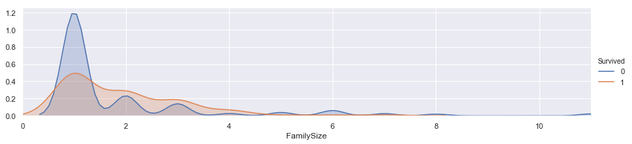

```python
facet = sns.FacetGrid(train, hue="Survived",aspect=4)
facet.map(sns.kdeplot,'FamilySize',shade= True)
facet.set(xlim=(0, train['FamilySize'].max()))
facet.add_legend()
plt.xlim(0)
```

#### FamilySize Scaling

```python
train['FamilySize'].describe()
```

```
count    891.000000
mean       1.904602
std        1.613459
min        1.000000
25%        1.000000
50%        1.000000
75%        2.000000
max       11.000000
Name: FamilySize, dtype: float64
```

```python
train['FamilySize'].value_counts()
```

```
1     537
2     161
3     102
4      29
6      22
5      15
7      12
11      7
8       6
Name: FamilySize, dtype: int64
```

```python
family_mapping = {1: 0, 2: 0.4, 3: 0.8, 4: 1.2, 5: 1.6, 6: 2, 7: 2.4, 8: 2.8, 9: 3.2, 10: 3.6, 11: 4}
for dataset in train_test_data:
    dataset['FamilySize'] = dataset['FamilySize'].map(family_mapping)
```

```python
train['FamilySize'].value_counts()
```

```
0.0    537
0.4    161
0.8    102
1.2     29
2.0     22
1.6     15
2.4     12
4.0      7
2.8      6
Name: FamilySize, dtype: int64
```

```python
train.head()
```

|  | PassengerId | Survived | Pclass | Sex | Age | SibSp | Parch | Ticket | Fare | Cabin | Embarked | Title | FamilySize |
| --- | --- | --- | --- | --- | --- | --- | --- | --- | --- | --- | --- | --- | --- |
| 0 | 1 | 0 | 3 | 0 | 1.0 | 1 | 0 | A/5 21171 | 7.2500 | 2.0 | 0 | 0 | 0.4 |
| 1 | 2 | 1 | 1 | 1 | 3.0 | 1 | 0 | PC 17599 | 71.2833 | 0.8 | 1 | 2 | 0.4 |
| 2 | 3 | 1 | 3 | 1 | 1.0 | 0 | 0 | STON/O2. 3101282 | 7.9250 | 2.0 | 0 | 1 | 0.0 |
| 3 | 4 | 1 | 1 | 1 | 2.0 | 1 | 0 | 113803 | 53.1000 | 0.8 | 0 | 2 | 0.4 |
| 4 | 5 | 0 | 3 | 0 | 2.0 | 0 | 0 | 373450 | 8.0500 | 2.0 | 0 | 0 | 0.0 |

```python
train.head()
```

|  | PassengerId | Survived | Pclass | Sex | Age | SibSp | Parch | Ticket | Fare | Cabin | Embarked | Title | FamilySize |
| --- | --- | --- | --- | --- | --- | --- | --- | --- | --- | --- | --- | --- | --- |
| 0 | 1 | 0 | 3 | 0 | 1.0 | 1 | 0 | A/5 21171 | 7.2500 | 2.0 | 0 | 0 | 0.4 |
| 1 | 2 | 1 | 1 | 1 | 3.0 | 1 | 0 | PC 17599 | 71.2833 | 0.8 | 1 | 2 | 0.4 |
| 2 | 3 | 1 | 3 | 1 | 1.0 | 0 | 0 | STON/O2. 3101282 | 7.9250 | 2.0 | 0 | 1 | 0.0 |
| 3 | 4 | 1 | 1 | 1 | 2.0 | 1 | 0 | 113803 | 53.1000 | 0.8 | 0 | 2 | 0.4 |
| 4 | 5 | 0 | 3 | 0 | 2.0 | 0 | 0 | 373450 | 8.0500 | 2.0 | 0 | 0 | 0.0 |

## columns drop

```python
features_drop = ['Ticket', 'SibSp', 'Parch']
train = train.drop(features_drop, axis=1)
test = test.drop(features_drop, axis=1)
train = train.drop(['PassengerId'], axis=1)
```

```python
train_data = train.drop('Survived', axis=1)
# Survived 만 별도 시리즈로 저장
target = train['Survived']

train_data.shape, target.shape
```

```
((891, 8), (891,))
```

```python
# target
```

```python
train_data.head(10)
```

|  | Pclass | Sex | Age | Fare | Cabin | Embarked | Title | FamilySize |
| --- | --- | --- | --- | --- | --- | --- | --- | --- |
| 0 | 3 | 0 | 1.0 | 7.2500 | 2.0 | 0 | 0 | 0.4 |
| 1 | 1 | 1 | 3.0 | 71.2833 | 0.8 | 1 | 2 | 0.4 |
| 2 | 3 | 1 | 1.0 | 7.9250 | 2.0 | 0 | 1 | 0.0 |
| 3 | 1 | 1 | 2.0 | 53.1000 | 0.8 | 0 | 2 | 0.4 |
| 4 | 3 | 0 | 2.0 | 8.0500 | 2.0 | 0 | 0 | 0.0 |
| 5 | 3 | 0 | 2.0 | 8.4583 | 2.0 | 2 | 0 | 0.0 |
| 6 | 1 | 0 | 3.0 | 51.8625 | 1.6 | 0 | 0 | 0.0 |
| 7 | 3 | 0 | 0.0 | 21.0750 | 2.0 | 0 | 3 | 1.6 |
| 8 | 3 | 1 | 2.0 | 11.1333 | 2.0 | 0 | 2 | 0.8 |
| 9 | 2 | 1 | 0.0 | 30.0708 | 1.8 | 1 | 2 | 0.4 |

# Modelling

- pip install sklearn (Anaconda X)

```python
# Importing Classifier Modules
from sklearn.neighbors import KNeighborsClassifier
from sklearn.tree import DecisionTreeClassifier
from sklearn.ensemble import RandomForestClassifier
from sklearn.naive_bayes import GaussianNB
from sklearn.svm import SVC

import numpy as np
```

```python
train.info()
```

```
<class 'pandas.core.frame.DataFrame'>
RangeIndex: 891 entries, 0 to 890
Data columns (total 9 columns):
Survived      891 non-null int64
Pclass        891 non-null int64
Sex           891 non-null int64
Age           891 non-null float64
Fare          891 non-null float64
Cabin         891 non-null float64
Embarked      891 non-null int64
Title         891 non-null int64
FamilySize    891 non-null float64
dtypes: float64(4), int64(5)
memory usage: 62.7 KB
```

```python
train.isnull().sum()
```

```
Survived      0
Pclass        0
Sex           0
Age           0
Fare          0
Cabin         0
Embarked      0
Title         0
FamilySize    0
dtype: int64
```

# Cross Validation (K-fold)

- 모델을 평가하는 방법
- 교차검증 => 과적합 해결
- 고정된 train set과 test set으로 평가를 하고, 반복적으로 모델을 튜닝하다보면 test set에만 과적합(Overfit)이 된다.
- 과적합을 해결하는 검증 데이타 생성 방법
- 전체 데이터 셋을 k개의 subset으로 나누고 k번의 평가를 실행. 이 때 test set을 중복 없이 바꾸어가면서 평가를 진행한다.

```python
Image(url="http://www.ibric.org/upload/geditor/201701/0.33966100_1485242514.png")
```

[figure not shown]

```python
from sklearn.model_selection import KFold
from sklearn.model_selection import cross_val_score

# 10개로 나누 경우
k_fold = KFold(n_splits=10, shuffle=True, random_state=0)
```

```python
# KFold?
# KFold
```

## kNN

- k-최근접 이웃 알고리즘
- 새로운 데이터를 입력받았을때 가장 가까이 있는 것은 무엇일까?

```python
Image(url='https://img1.daumcdn.net/thumb/R720x0.q80/?scode=mtistory2&fname=http%3A%2F%2Fcfile28.uf.tistory.com%2Fimage%2F99631D335A165F182D00A7')
```

[figure not shown]

```python
cross_val_score?
```

```python
clf = KNeighborsClassifier(n_neighbors = 13)
# scoring = 'accuracy'
score = cross_val_score(clf, train_data, target,
                        cv=k_fold, n_jobs=1, scoring='accuracy')
score
```

```
array([0.7       , 0.74157303, 0.7752809 , 0.69662921, 0.76404494,
       0.74157303, 0.76404494, 0.74157303, 0.74157303, 0.78651685])
```

```python
# kNN Score
round(np.mean(score)*100, 2)
```

```
74.53
```

## Decision Tree

- 의사결정나무
- 질문을 던져서 대상을 좁혀나가는 스무고개 놀이와 비슷한 개념

```python
Image(url="https://miro.medium.com/max/875/0*DKVni_-q7dAKVel7.png")
```

[figure not shown]

```python
clf = DecisionTreeClassifier()
score = cross_val_score(clf, train_data, target,
                        cv=k_fold, n_jobs=1, scoring='accuracy')
print(score)
```

```
[0.82222222 0.7752809  0.84269663 0.7752809  0.78651685 0.80898876
 0.82022472 0.82022472 0.76404494 0.82022472]
```

```python
# decision tree Score
round(np.mean(score)*100, 2)
```

```
80.36
```

## Ramdom Forest

- 다수의 결정 트리로부터 분류 또는 평균 예측치(회귀 분석)를 출력

```python
Image(url="https://upload.wikimedia.org/wikipedia/commons/3/36/%EB%9E%9C%EB%8D%A4%ED%8F%AC%EB%A0%88%EC%8A%A4%ED%8A%B8_%ED%95%99%EC%8A%B5%EA%B3%BC%EC%A0%95_%EB%B0%B0%EA%B9%85.png")
```

[figure not shown]

```python
clf = RandomForestClassifier(n_estimators=13)

score = cross_val_score(clf, train_data, target, cv=k_fold, n_jobs=1,
                        scoring='accuracy')
score
```

```
array([0.75555556, 0.82022472, 0.7752809 , 0.78651685, 0.85393258,
       0.78651685, 0.83146067, 0.82022472, 0.76404494, 0.80898876])
```

```python
# Random Forest Score
round(np.mean(score)*100, 2)
```

```
80.03
```

## Naive Bayes

- 나이브 베이즈 분류(Naïve Bayes Classification)
- 베이즈 정리를 적용한 확률 분류기

```python
clf = GaussianNB()

score = cross_val_score(clf, train_data, target, cv=k_fold,
                        n_jobs=1, scoring='accuracy')
print(score)
```

```
[0.82222222 0.74157303 0.7752809  0.75280899 0.74157303 0.83146067
 0.80898876 0.82022472 0.82022472 0.83146067]
```

```python
# Naive Bayes Score
round(np.mean(score)*100, 2)
```

```
79.46
```

## SVM

- 서포트 벡터 머신(support vector machine)
- 두 카테고리 중 어느 하나에 속한 데이터의 집합이 주어졌을 때, SVM 알고리즘은 주어진 데이터 집합을 바탕으로 하여 새로운 데이터가 어느 카테고리에 속할지 판단한다.

```python
Image(url="https://eight2late.files.wordpress.com/2016/12/svm-fig-1.png?w=700")
```

[figure not shown]

```python
clf = SVC()
score = cross_val_score(clf, train_data, target, cv=k_fold,
                        n_jobs=1, scoring='accuracy')
print(score)
```

```
[0.76666667 0.78651685 0.79775281 0.78651685 0.78651685 0.7752809
 0.85393258 0.80898876 0.75280899 0.84269663]
```

```python
round(np.mean(score)*100,2)
```

```
79.58
```

# Testing

```python
# 모델링
clf = SVC()
clf.fit(train_data, target)

# 검증
test_data = test.drop("PassengerId", axis=1).copy()
prediction = clf.predict(test_data)
```

#### csv 파일로 결과파일 저장하기

```python
submission = pd.DataFrame({
        "PassengerId": test["PassengerId"],
        "Survived": prediction
    })

submission.to_csv('submission.csv', index=False)
```

```python
submission = pd.read_csv('submission.csv')
submission.head()
```

|  | PassengerId | Survived |
| --- | --- | --- |
| 0 | 892 | 0 |
| 1 | 893 | 0 |
| 2 | 894 | 0 |
| 3 | 895 | 0 |
| 4 | 896 | 1 |

### 사용자정의 결과 예측하기

```python
test.columns
# len(test.columns)
```

```
Index(['PassengerId', 'Pclass', 'Sex', 'Age', 'Fare', 'Cabin', 'Embarked',
       'Title', 'FamilySize'],
      dtype='object')
```

```python
# 'Pclass', 'Sex', 'Age', 'Fare', 'Cabin', 'Embarked',
#  Title', 'FamilySize'
dicaprio = [[3., 0., 1., 0., 0., 1., 0, 0]]
winslet = [[1., 1., 1., 2., 1., 1., 2, 1]]
```

```python
# clf = SVC()
# clf.fit(train_data, target)

test_data = pd.DataFrame(winslet, \
                         columns=['Pclass', 'Sex', 'Age', \
                                  'Fare', 'Cabin', 'Embarked', \
                                   'Title', 'FamilySize'])
test_data
```

|  | Pclass | Sex | Age | Fare | Cabin | Embarked | Title | FamilySize |
| --- | --- | --- | --- | --- | --- | --- | --- | --- |
| 0 | 1.0 | 1.0 | 1.0 | 2.0 | 1.0 | 1.0 | 2 | 1 |

```python
prediction = clf.predict(test_data)
prediction[0]
```

```
0
```

## 함수화

```python
def isSurvived(PassengerInfo):
    test_data = pd.DataFrame(PassengerInfo, \
                         columns=['Pclass', 'Sex', 'Age', \
                                  'Fare', 'Cabin', 'Embarked', \
                                   'Title', 'FamilySize'])
    prediction = clf.predict(test_data)
    if prediction[0]:
        print(PassengerInfo)
        print('Result = not survived')
    else:
        print(PassengerInfo)
        print('Result = Survived')

isSurvived(dicaprio)
isSurvived(winslet)
```

[output not shown]